# A6 Means and SD’s across QRP

Gerko Vink

# Packages used

For this document we use the following packages

```r
library(dplyr)    # Data manipulation
library(mice)     # Data imputation
library(magrittr) # Pipes
library(purrr)    # Functional programming
library(haven)    # Import data
library(DT)       # Interactive tables
library(ggplot2)  # Plotting device
library(reshape2) # Data shaping
library(labelled) # Advanced labelling
library(psych)    # Descriptives
library(tibble)   # Dataframes on steroids
library(gtools)   # Useful tools
library(DT)       # HTML tables
```

# Load the data

```r
load(file = "../Workspaces/3. Data imputation.Rdata")
load(file = "../Workspaces/2. Data inspection.Rdata")
```

# QRP with and without `NA`’s

We consider **both the cases with and without `Not Applicable`’s** in this document. First, we create an indicator for all QRP

```r
QRP_set <- names(raw_data[86:107])[-c(1, 2, 4, 6, 9, 12, 15, 16, 17, 19, 21 )]
```

## Descriptives and plots

### Overall

First, we calculate the descriptive statistics of the data **with `Not Applicable`’s**

```r
mice::complete(imp, 1) %>% #QRP has no missings -so use 1st imputed set
  select(all_of(QRP_set)) %>%
  rowMeans(na.rm = FALSE) %>% #no missings
  describe() %>% .[, 2:5] %>%
  print.data.frame()
```

```
##       n    mean        sd   median
## X1 6813 1.78892 0.7052643 1.727273
```

Second, we print the means and SD’s for the data without the rows that contain `Not Applicable`’s.

```r
mice::complete(imp, 1) %>% #QRP has no missings -so use 1st imputed set
  select(all_of(QRP_set)) %>%
  na_if(0) %>%
  rowMeans(na.rm = FALSE) %>% #i.e. listwise deletion of incomplete rows
  describe() %>% .[, 2:5] %>%
  print.data.frame()
```

```
##       n     mean       sd median
## X1 3033 2.097653 0.654186      2
```

Third, we consider the means and SD’s for the QRP’s for the data without the rows that contain `Not Applicable`’s where for each row the mean is calculated based on the observed (i.e. applicable) values.

```r
mice::complete(imp, 1) %>% #QRP has no missings -so use 1st imputed set
  select(all_of(QRP_set)) %>%
  na_if(0) %>%
  rowMeans(na.rm = TRUE) %>% #i.e. casewise deletion of unobserved values in row
  describe() %>% .[, 2:5] %>%
  print.data.frame()
```

```
##       n     mean        sd median
## X1 6769 2.042289 0.6844935      2
```

### By disciplinary field

First, we calculate the descriptive statistics of the data **with `Not Applicable`’s**

```
##                                 D2 count     mean        sd
## 1   Social and Behavioral Sciences  1965 1.768494 0.6880967
## 2              Arts and Humanities   636 1.448113 0.7109644
## 3 Engineering and Natural Sciences  1465 1.756624 0.7466460
## 4     Biomedical and Life Sciences  2747 1.899659 0.6641738
```

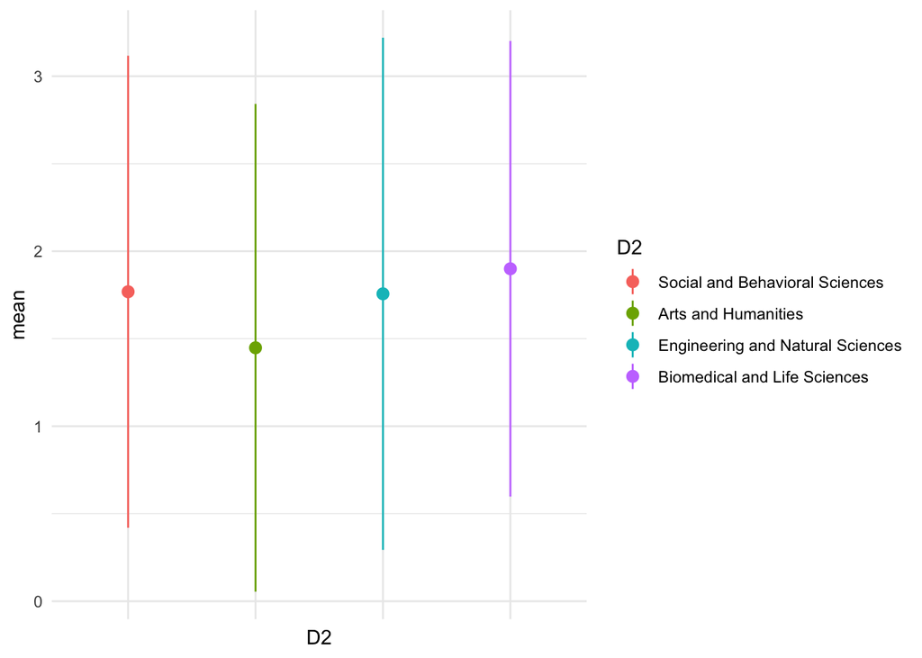

```r
mice::complete(imp, 1) %>% #QRP has no missings -so use 1st imputed set
  select(D2, all_of(QRP_set)) %>%
  mutate(rowM = rowMeans(select(., all_of(QRP_set)), na.rm = FALSE)) %>%
  select(D2, rowM) %>%
  melt(id.vars = "D2", value.name = "QRP_mean") %>%
  group_by(D2) %>%
  summarise(count = n(),
            mean = mean(QRP_mean, na.rm=TRUE),
            sd = sd(QRP_mean, na.rm = TRUE))  %T>%
  print.data.frame() %>%
  ggplot(aes(x = D2, y = mean,
             ymin = mean - 1.96*sd,
             ymax = mean + 1.96*sd)) +
  geom_pointrange(aes(group = D2, colour = D2),
                  position = position_dodge(width = 1)) +
  theme_minimal() +
  theme(axis.text.x = element_blank(), axis.ticks = element_blank())
```

Second, we print the means and SD’s for the data without the rows that contain `Not Applicable`’s.

```
##                                 D2 count     mean        sd
## 1   Social and Behavioral Sciences  1965 2.063227 0.6397430
## 2              Arts and Humanities   636 2.066434 0.6945681
## 3 Engineering and Natural Sciences  1465 2.148343 0.7557260
## 4     Biomedical and Life Sciences  2747 2.100445 0.6202891
```

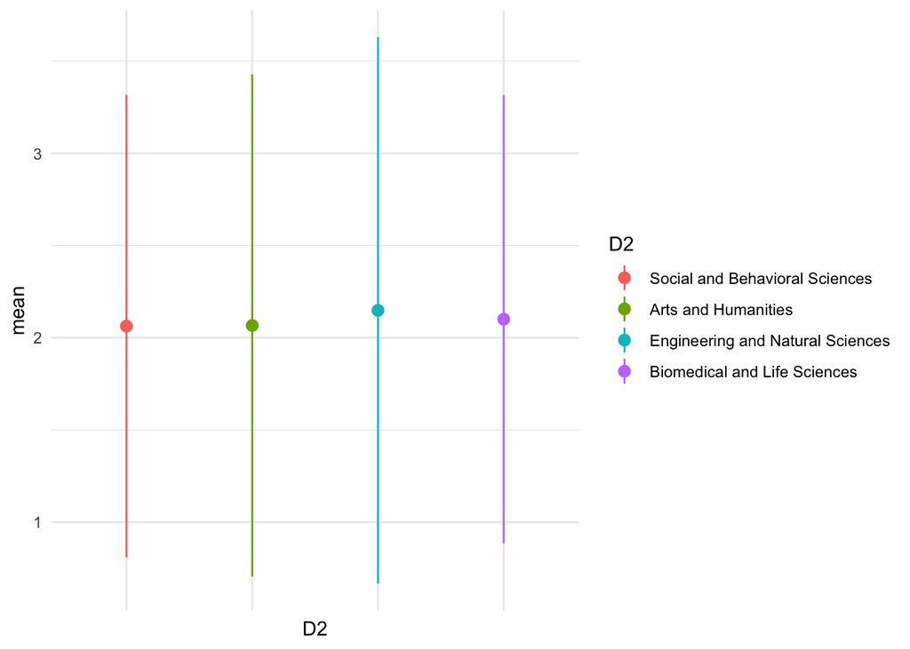

```r
mice::complete(imp, 1) %>% #QRP has no missings -so use 1st imputed set
  select(D2, all_of(QRP_set)) %>%
  na_if(0) %>%
  mutate(rowM = rowMeans(select(., all_of(QRP_set)), na.rm = FALSE)) %>%
  select(D2, rowM) %>%
  melt(id.vars = "D2", value.name = "QRP_mean") %>%
  group_by(D2) %>%
  summarise(count = n(),
            mean = mean(QRP_mean, na.rm=TRUE),
            sd = sd(QRP_mean, na.rm = TRUE))  %T>%
  print.data.frame() %>%
  ggplot(aes(x = D2, y = mean,
             ymin = mean - 1.96*sd,
             ymax = mean + 1.96*sd)) +
  geom_pointrange(aes(group = D2, colour = D2),
                  position = position_dodge(width = 1)) +
  theme_minimal() +
  theme(axis.text.x = element_blank(), axis.ticks = element_blank())
```

Third, we consider the means and SD’s for the QRP’s where only missing cases are excluded from calculating the rowwise mean.

```
##                                 D2 count     mean        sd
## 1   Social and Behavioral Sciences  1965 2.015855 0.6774218
## 2              Arts and Humanities   636 1.927240 0.7451907
## 3 Engineering and Natural Sciences  1465 2.030981 0.7269684
## 4     Biomedical and Life Sciences  2747 2.093855 0.6463334
```

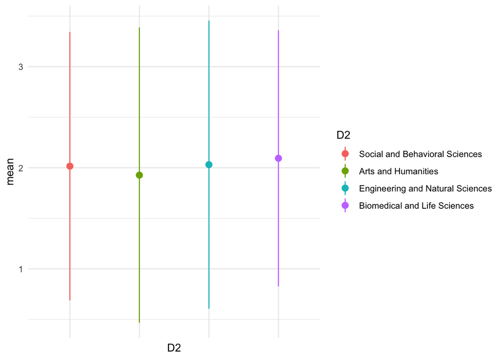

```r
mice::complete(imp, 1) %>% #QRP has no missings -so use 1st imputed set
  select(D2, all_of(QRP_set)) %>%
  na_if(0) %>%
  mutate(rowM = rowMeans(select(., all_of(QRP_set)), na.rm = TRUE)) %>%
  select(D2, rowM) %>%
  melt(id.vars = "D2", value.name = "QRP_mean") %>%
  group_by(D2) %>%
  summarise(count = n(),
            mean = mean(QRP_mean, na.rm=TRUE),
            sd = sd(QRP_mean, na.rm = TRUE)) %T>%
  print.data.frame() %>%
  ggplot(aes(x = D2, y = mean,
             ymin = mean - 1.96*sd,
             ymax = mean + 1.96*sd)) +
  geom_pointrange(aes(group = D2, colour = D2),
                  position = position_dodge(width = 1)) +
  theme_minimal() +
  theme(axis.text.x = element_blank(), axis.ticks = element_blank())
```

### By rank

First, we calculate the descriptive statistics of the data **with `Not Applicable`’s**

```
##                                                                                          D3
## 1                                                          PhD student or junior researcher
## 2 Postdoctoral researcher, Assistant Professor, Physician Researcher or Lecturer Researcher
## 3                                                     Associate Professor or Full Professor
##   count     mean        sd
## 1  2013 1.705324 0.7589421
## 2  2733 1.849749 0.6818370
## 3  2067 1.789902 0.6727594
```

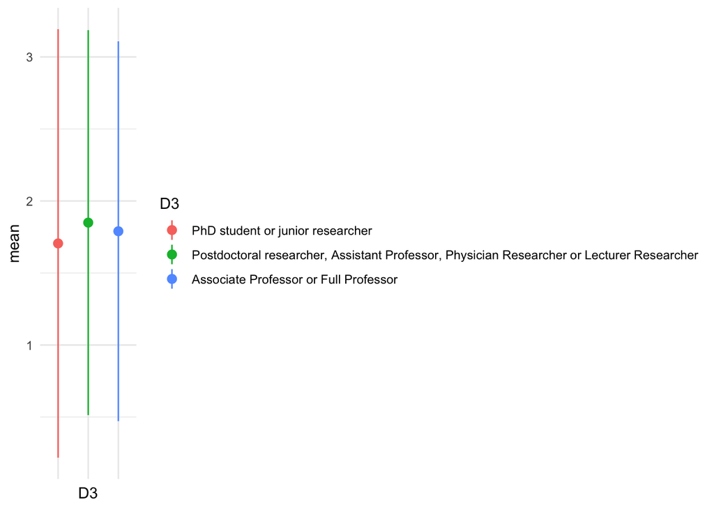

```r
mice::complete(imp, 1) %>% #QRP has no missings -so use 1st imputed set
  select(D3, all_of(QRP_set)) %>%
  mutate(rowM = rowMeans(select(., all_of(QRP_set)), na.rm = FALSE)) %>%
  select(D3, rowM) %>%
  melt(id.vars = "D3", value.name = "QRP_mean") %>%
  group_by(D3) %>%
  summarise(count = n(),
            mean = mean(QRP_mean, na.rm=TRUE),
            sd = sd(QRP_mean, na.rm = TRUE))  %T>%
  print.data.frame() %>%
  ggplot(aes(x = D3, y = mean,
             ymin = mean - 1.96*sd,
             ymax = mean + 1.96*sd)) +
  geom_pointrange(aes(group = D3, colour = D3),
                  position = position_dodge(width = 1)) +
  theme_minimal() +
  theme(axis.text.x = element_blank(), axis.ticks = element_blank())
```

Second, we print the means and SD’s for the data without the rows that contain `Not Applicable`’s.

```
##                                                                                          D3
## 1                                                          PhD student or junior researcher
## 2 Postdoctoral researcher, Assistant Professor, Physician Researcher or Lecturer Researcher
## 3                                                     Associate Professor or Full Professor
##   count     mean        sd
## 1  2013 2.254545 0.7108217
## 2  2733 2.108172 0.6364624
## 3  2067 2.020704 0.6386765
```

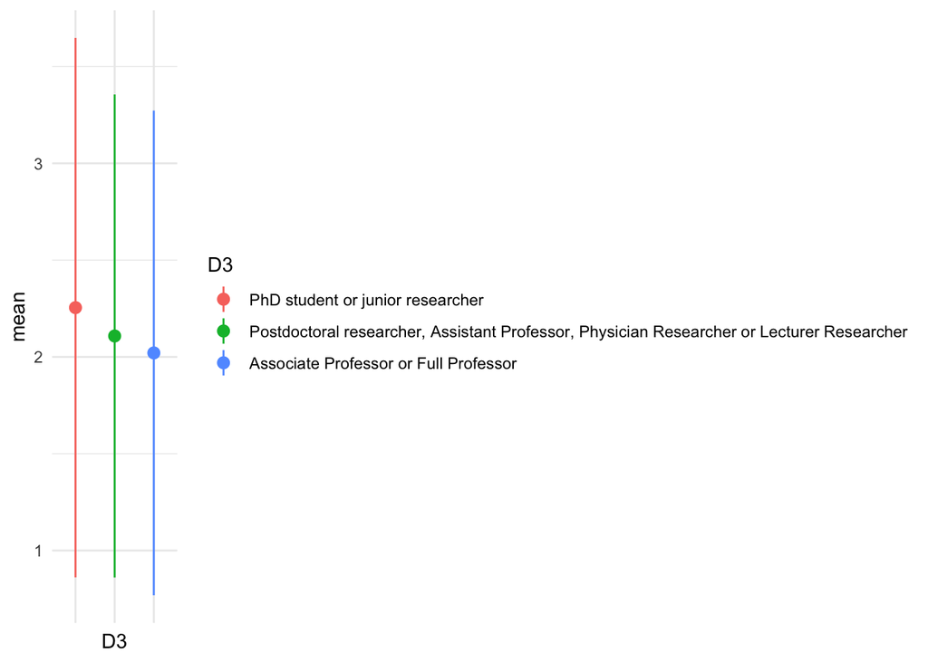

```r
mice::complete(imp, 1) %>% #QRP has no missings -so use 1st imputed set
  select(D3, all_of(QRP_set)) %>%
  na_if(0) %>%
  mutate(rowM = rowMeans(select(., all_of(QRP_set)), na.rm = FALSE)) %>%
  select(D3, rowM) %>%
  melt(id.vars = "D3", value.name = "QRP_mean") %>%
  group_by(D3) %>%
  summarise(count = n(),
            mean = mean(QRP_mean, na.rm=TRUE),
            sd = sd(QRP_mean, na.rm = TRUE))  %T>%
  print.data.frame() %>%
  ggplot(aes(x = D3, y = mean,
             ymin = mean - 1.96*sd,
             ymax = mean + 1.96*sd)) +
  geom_pointrange(aes(group = D3, colour = D3),
                  position = position_dodge(width = 1)) +
  theme_minimal() +
  theme(axis.text.x = element_blank(), axis.ticks = element_blank())
```

Third, we consider the means and SD’s for the QRP’s where only missing cases are excluded from calculating the rowwise mean.

```
##                                                                                          D3
## 1                                                          PhD student or junior researcher
## 2 Postdoctoral researcher, Assistant Professor, Physician Researcher or Lecturer Researcher
## 3                                                     Associate Professor or Full Professor
##   count     mean        sd
## 1  2013 2.183813 0.7434806
## 2  2733 2.025758 0.6552681
## 3  2067 1.929257 0.6389240
```

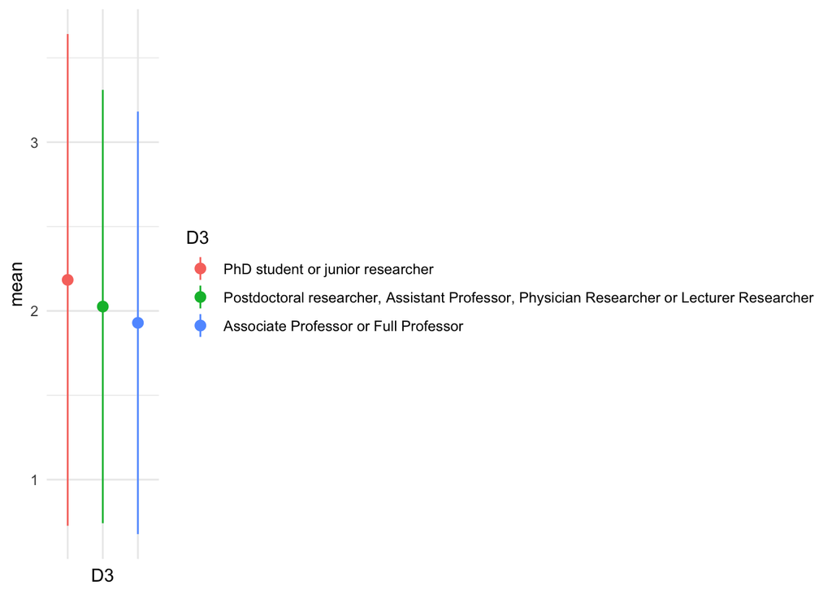

```r
mice::complete(imp, 1) %>% #QRP has no missings -so use 1st imputed set
  select(D3, all_of(QRP_set)) %>%
  na_if(0) %>%
  mutate(rowM = rowMeans(select(., all_of(QRP_set)), na.rm = TRUE)) %>%
  select(D3, rowM) %>%
  melt(id.vars = "D3", value.name = "QRP_mean") %>%
  group_by(D3) %>%
  summarise(count = n(),
            mean = mean(QRP_mean, na.rm=TRUE),
            sd = sd(QRP_mean, na.rm = TRUE)) %T>%
  print.data.frame() %>%
  ggplot(aes(x = D3, y = mean,
             ymin = mean - 1.96*sd,
             ymax = mean + 1.96*sd)) +
  geom_pointrange(aes(group = D3, colour = D3),
                  position = position_dodge(width = 1)) +
  theme_minimal() +
  theme(axis.text.x = element_blank(), axis.ticks = element_blank())
```

### By gender identification

First, we calculate the descriptive statistics of the data **with `Not Applicable`’s**

```
##                                D4 count     mean        sd
## 1                          Female  3008 1.763963 0.7005397
## 2                            Male  3689 1.812021 0.7078465
## 3 Other / Do not wish to disclose   116 1.701411 0.7221963
```

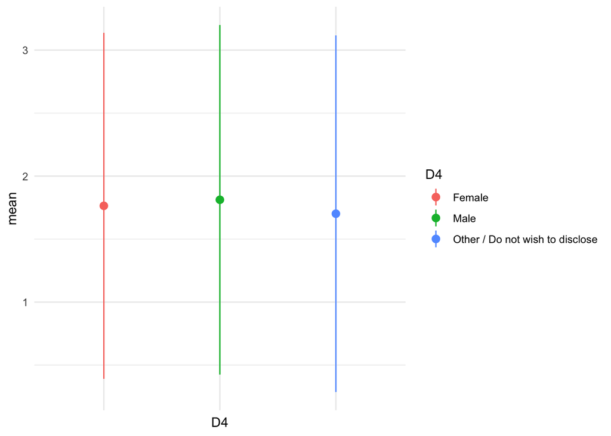

```r
mice::complete(imp, 1) %>% #QRP has no missings -so use 1st imputed set
  select(D4, all_of(QRP_set)) %>%
  mutate(rowM = rowMeans(select(., all_of(QRP_set)), na.rm = FALSE)) %>%
  select(D4, rowM) %>%
  melt(id.vars = "D4", value.name = "QRP_mean") %>%
  group_by(D4) %>%
  summarise(count = n(),
            mean = mean(QRP_mean, na.rm=TRUE),
            sd = sd(QRP_mean, na.rm = TRUE))  %T>%
  print.data.frame() %>%
  ggplot(aes(x = D4, y = mean,
             ymin = mean - 1.96*sd,
             ymax = mean + 1.96*sd)) +
  geom_pointrange(aes(group = D4, colour = D4),
                  position = position_dodge(width = 1)) +
  theme_minimal() +
  theme(axis.text.x = element_blank(), axis.ticks = element_blank())
```

Second, we print the means and SD’s for the data without the rows that contain `Not Applicable`’s.

```
##                                D4 count     mean        sd
## 1                          Female  3008 2.078275 0.6387097
## 2                            Male  3689 2.109794 0.6674467
## 3 Other / Do not wish to disclose   116 2.164773 0.5593511
```

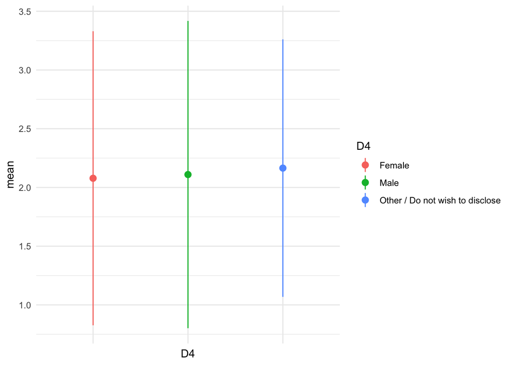

```r
mice::complete(imp, 1) %>% #QRP has no missings -so use 1st imputed set
  select(D4, all_of(QRP_set)) %>%
  na_if(0) %>%
  mutate(rowM = rowMeans(select(., all_of(QRP_set)), na.rm = FALSE)) %>%
  select(D4, rowM) %>%
  melt(id.vars = "D4", value.name = "QRP_mean") %>%
  group_by(D4) %>%
  summarise(count = n(),
            mean = mean(QRP_mean, na.rm=TRUE),
            sd = sd(QRP_mean, na.rm = TRUE))  %T>%
  print.data.frame() %>%
  ggplot(aes(x = D4, y = mean,
             ymin = mean - 1.96*sd,
             ymax = mean + 1.96*sd)) +
  geom_pointrange(aes(group = D4, colour = D4),
                  position = position_dodge(width = 1)) +
  theme_minimal() +
  theme(axis.text.x = element_blank(), axis.ticks = element_blank())
```

Third, we consider the means and SD’s for the QRP’s where only missing cases are excluded from calculating the rowwise mean.

```
##                                D4 count     mean        sd
## 1                          Female  3008 2.044528 0.6877770
## 2                            Male  3689 2.042581 0.6834348
## 3 Other / Do not wish to disclose   116 1.975482 0.6335693
```

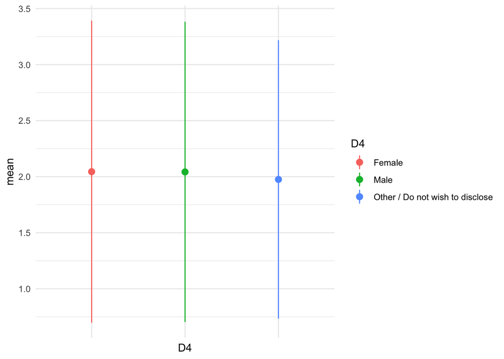

```r
mice::complete(imp, 1) %>% #QRP has no missings -so use 1st imputed set
  select(D4, all_of(QRP_set)) %>%
  na_if(0) %>%
  mutate(rowM = rowMeans(select(., all_of(QRP_set)), na.rm = TRUE)) %>%
  select(D4, rowM) %>%
  melt(id.vars = "D4", value.name = "QRP_mean") %>%
  group_by(D4) %>%
  summarise(count = n(),
            mean = mean(QRP_mean, na.rm=TRUE),
            sd = sd(QRP_mean, na.rm = TRUE)) %T>%
  print.data.frame() %>%
  ggplot(aes(x = D4, y = mean,
             ymin = mean - 1.96*sd,
             ymax = mean + 1.96*sd)) +
  geom_pointrange(aes(group = D4, colour = D4),
                  position = position_dodge(width = 1)) +
  theme_minimal() +
  theme(axis.text.x = element_blank(), axis.ticks = element_blank())
```

### By empirical research engagement

First, we calculate the descriptive statistics of the data **with `Not Applicable`’s**

```
##    D5 count     mean        sd
## 1 Yes  6083 1.832036 0.6788794
## 2  No   730 1.429639 0.8111698
```

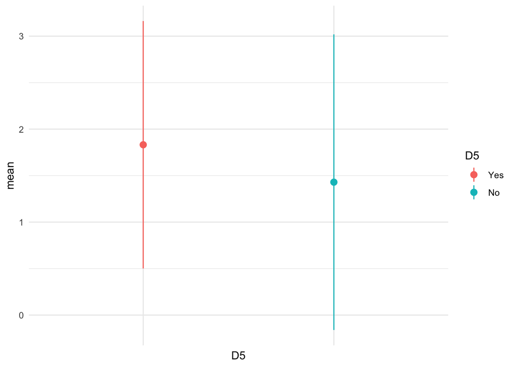

```r
mice::complete(imp, 1) %>% #QRP has no missings -so use 1st imputed set
  select(D5, all_of(QRP_set)) %>%
  mutate(rowM = rowMeans(select(., all_of(QRP_set)), na.rm = FALSE)) %>%
  select(D5, rowM) %>%
  melt(id.vars = "D5", value.name = "QRP_mean") %>%
  group_by(D5) %>%
  summarise(count = n(),
            mean = mean(QRP_mean, na.rm=TRUE),
            sd = sd(QRP_mean, na.rm = TRUE))  %T>%
  print.data.frame() %>%
  ggplot(aes(x = D5, y = mean,
             ymin = mean - 1.96*sd,
             ymax = mean + 1.96*sd)) +
  geom_pointrange(aes(group = D5, colour = D5),
                  position = position_dodge(width = 1)) +
  theme_minimal() +
  theme(axis.text.x = element_blank(), axis.ticks = element_blank())
```

Second, we print the means and SD’s for the data without the rows that contain `Not Applicable`’s.

```
##    D5 count     mean        sd
## 1 Yes  6083 2.088723 0.6478070
## 2  No   730 2.310730 0.7639011
```

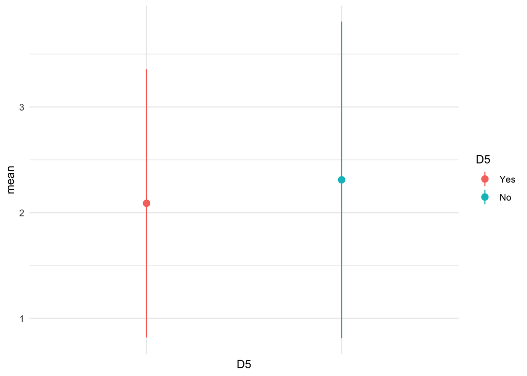

```r
mice::complete(imp, 1) %>% #QRP has no missings -so use 1st imputed set
  select(D5, all_of(QRP_set)) %>%
  na_if(0) %>%
  mutate(rowM = rowMeans(select(., all_of(QRP_set)), na.rm = FALSE)) %>%
  select(D5, rowM) %>%
  melt(id.vars = "D5", value.name = "QRP_mean") %>%
  group_by(D5) %>%
  summarise(count = n(),
            mean = mean(QRP_mean, na.rm=TRUE),
            sd = sd(QRP_mean, na.rm = TRUE))  %T>%
  print.data.frame() %>%
  ggplot(aes(x = D5, y = mean,
             ymin = mean - 1.96*sd,
             ymax = mean + 1.96*sd)) +
  geom_pointrange(aes(group = D5, colour = D5),
                  position = position_dodge(width = 1)) +
  theme_minimal() +
  theme(axis.text.x = element_blank(), axis.ticks = element_blank())
```

Third, we consider the means and SD’s for the QRP’s where only missing cases are excluded from calculating the rowwise mean.

```
##    D5 count     mean        sd
## 1 Yes  6083 2.052162 0.6722416
## 2  No   730 1.958567 0.7761971
```

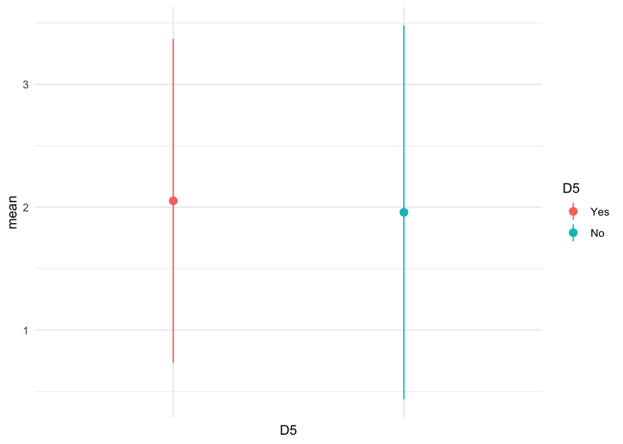

```r
mice::complete(imp, 1) %>% #QRP has no missings -so use 1st imputed set
  select(D5, all_of(QRP_set)) %>%
  na_if(0) %>%
  mutate(rowM = rowMeans(select(., all_of(QRP_set)), na.rm = TRUE)) %>%
  select(D5, rowM) %>%
  melt(id.vars = "D5", value.name = "QRP_mean") %>%
  group_by(D5) %>%
  summarise(count = n(),
            mean = mean(QRP_mean, na.rm=TRUE),
            sd = sd(QRP_mean, na.rm = TRUE)) %T>%
  print.data.frame() %>%
  ggplot(aes(x = D5, y = mean,
             ymin = mean - 1.96*sd,
             ymax = mean + 1.96*sd)) +
  geom_pointrange(aes(group = D5, colour = D5),
                  position = position_dodge(width = 1)) +
  theme_minimal() +
  theme(axis.text.x = element_blank(), axis.ticks = element_blank())
```

### By institutional support

First, we calculate the descriptive statistics of the data **with `Not Applicable`’s**

```
##               Group count     mean        sd
## 1     Joining group  3270 1.775063 0.6995671
## 2 Non-joining group  3543 1.801709 0.7103408
```

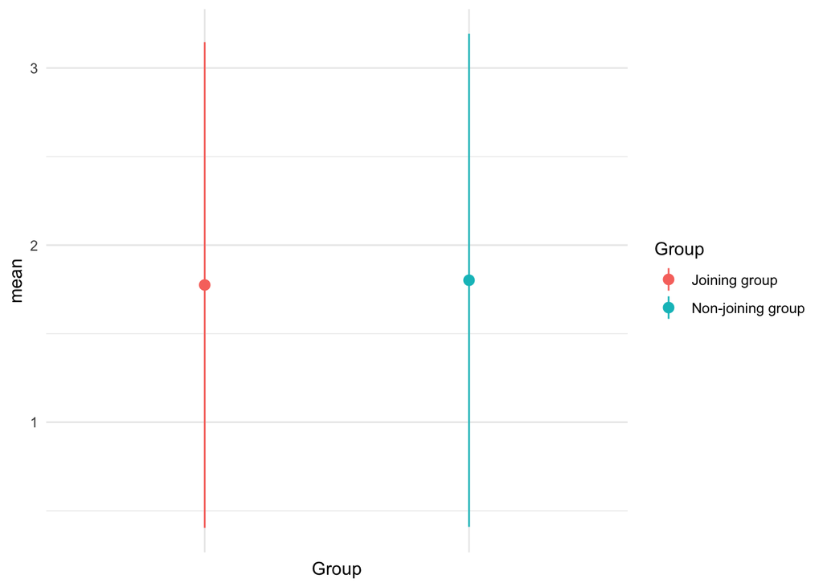

```r
mice::complete(imp, 1) %>% #QRP has no missings -so use 1st imputed set
  select(Group, all_of(QRP_set)) %>%
  mutate(rowM = rowMeans(select(., all_of(QRP_set)), na.rm = FALSE)) %>%
  select(Group, rowM) %>%
  melt(id.vars = "Group", value.name = "QRP_mean") %>%
  group_by(Group) %>%
  summarise(count = n(),
            mean = mean(QRP_mean, na.rm=TRUE),
            sd = sd(QRP_mean, na.rm = TRUE))  %T>%
  print.data.frame() %>%
  ggplot(aes(x = Group, y = mean,
             ymin = mean - 1.96*sd,
             ymax = mean + 1.96*sd)) +
  geom_pointrange(aes(group = Group, colour = Group),
                  position = position_dodge(width = 1)) +
  theme_minimal() +
  theme(axis.text.x = element_blank(), axis.ticks = element_blank())
```

Second, we print the means and SD’s for the data without the rows that contain `Not Applicable`’s.

```
##               Group count     mean        sd
## 1     Joining group  3270 2.083662 0.6342330
## 2 Non-joining group  3543 2.110134 0.6714369
```

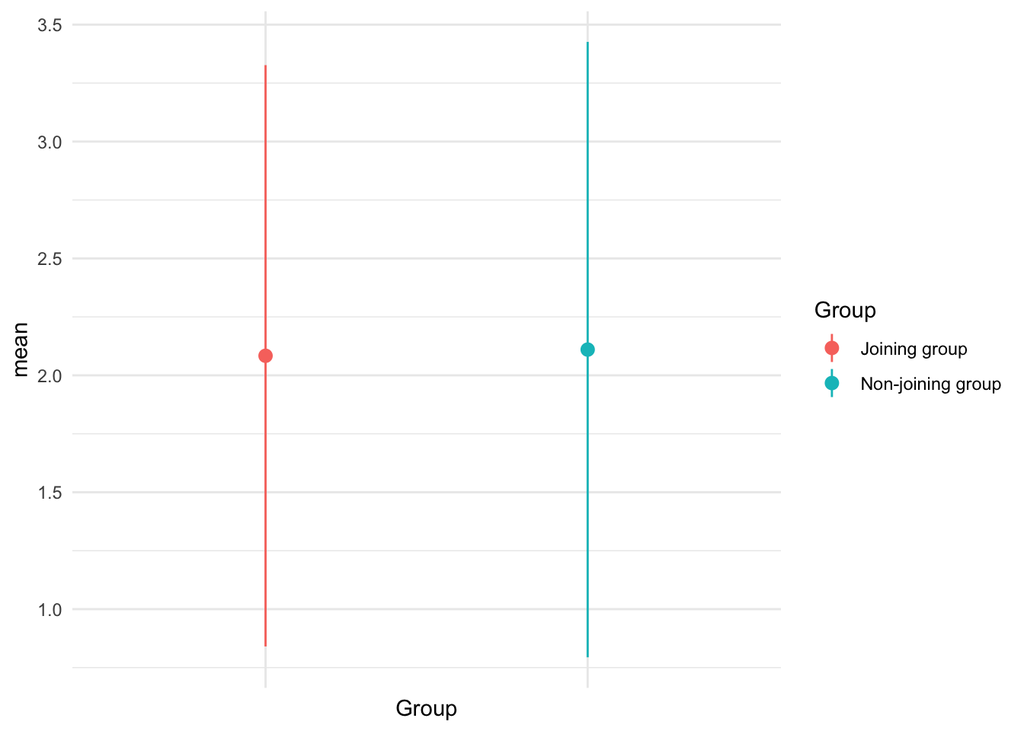

```r
mice::complete(imp, 1) %>% #QRP has no missings -so use 1st imputed set
  select(Group, all_of(QRP_set)) %>%
  na_if(0) %>%
  mutate(rowM = rowMeans(select(., all_of(QRP_set)), na.rm = FALSE)) %>%
  select(Group, rowM) %>%
  melt(id.vars = "Group", value.name = "QRP_mean") %>%
  group_by(Group) %>%
  summarise(count = n(),
            mean = mean(QRP_mean, na.rm=TRUE),
            sd = sd(QRP_mean, na.rm = TRUE))  %T>%
  print.data.frame() %>%
  ggplot(aes(x = Group, y = mean,
             ymin = mean - 1.96*sd,
             ymax = mean + 1.96*sd)) +
  geom_pointrange(aes(group = Group, colour = Group),
                  position = position_dodge(width = 1)) +
  theme_minimal() +
  theme(axis.text.x = element_blank(), axis.ticks = element_blank())
```

Third, we consider the means and SD’s for the QRP’s where only missing cases are excluded from calculating the rowwise mean.

```
##               Group count     mean        sd
## 1     Joining group  3270 2.051308 0.6733857
## 2 Non-joining group  3543 2.034004 0.6945334
```

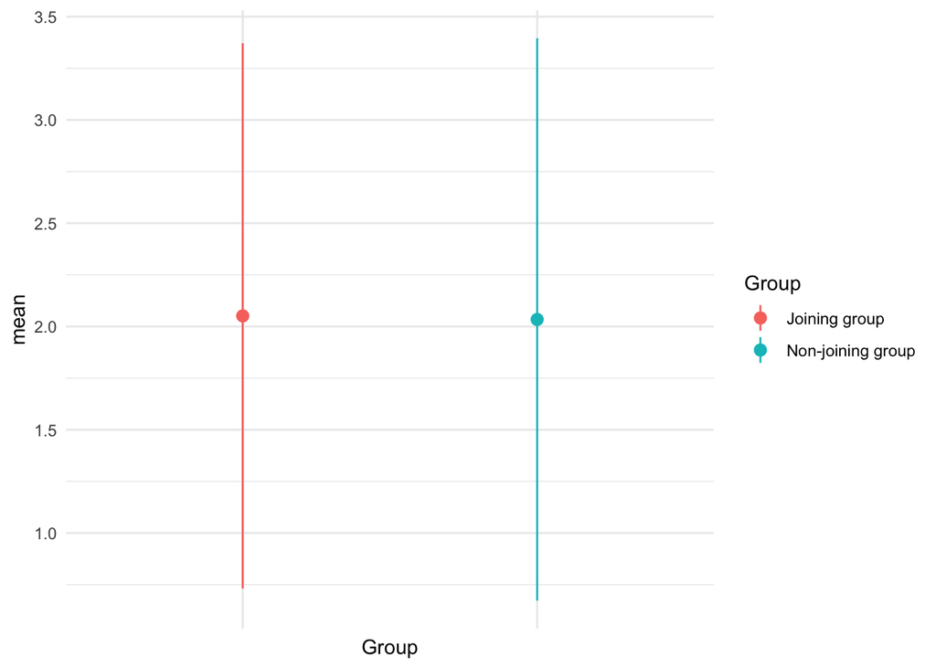

```r
mice::complete(imp, 1) %>% #QRP has no missings -so use 1st imputed set
  select(Group, all_of(QRP_set)) %>%
  na_if(0) %>%
  mutate(rowM = rowMeans(select(., all_of(QRP_set)), na.rm = TRUE)) %>%
  select(Group, rowM) %>%
  melt(id.vars = "Group", value.name = "QRP_mean") %>%
  group_by(Group) %>%
  summarise(count = n(),
            mean = mean(QRP_mean, na.rm=TRUE),
            sd = sd(QRP_mean, na.rm = TRUE)) %T>%
  print.data.frame() %>%
  ggplot(aes(x = Group, y = mean,
             ymin = mean - 1.96*sd,
             ymax = mean + 1.96*sd)) +
  geom_pointrange(aes(group = Group, colour = Group),
                  position = position_dodge(width = 1)) +
  theme_minimal() +
  theme(axis.text.x = element_blank(), axis.ticks = element_blank())
```

# Document info

Signed: [Gerko Vink](https://www.gerkovink.com),

```r
timestamp()
```

```
## ##------ Tue Apr  6 20:40:36 2021 ------##
```

END of DOCUMENT